# COMPSCIX 415.2 Homework 4

Gregory Spathias

July 3, 2018

```r
library(tidyverse)
library(mdsr)
file_path <- 'C:/Users/Gregory Spathias/Documents/compscix-415-2-assignments/Homework/flights.csv'
flights <- read.csv(file = file_path)
```

## **Section 5.6.7**

```r
not_cancelled <- flights %>%
  filter(!is.na(dep_delay), !is.na(arr_delay))
```

### **5.6.7.2**

a.Original

```r
not_cancelled %>% count(dest)
```

```
## # A tibble: 85 x 2
##    dest      n
##    <fct> <int>
##  1 ALB       3
##  2 ATL      50
##  3 AUS       7
##  4 AVL       1
##  5 BDL       2
##  6 BNA      11
##  7 BOS      29
##  8 BQN       4
##  9 BTV       8
## 10 BUF      17
## # ... with 75 more rows
```

a.Another Way:

```r
not_cancelled %>% group_by(dest) %>% summarise(n = n())
```

```
## # A tibble: 85 x 2
##    dest      n
##    <fct> <int>
##  1 ALB       3
##  2 ATL      50
##  3 AUS       7
##  4 AVL       1
##  5 BDL       2
##  6 BNA      11
##  7 BOS      29
##  8 BQN       4
##  9 BTV       8
## 10 BUF      17
## # ... with 75 more rows
```

b.Original

```r
not_cancelled %>% count(tailnum, wt = distance)
```

```
## # A tibble: 737 x 2
##    tailnum     n
##    <fct>   <int>
##  1 N0EGMQ   1088
##  2 N11107   1008
##  3 N11119    419
##  4 N11189   1353
##  5 N11193    628
##  6 N11206   1085
##  7 N11536   1072
##  8 N11544    845
##  9 N11551    368
## 10 N11565    569
## # ... with 727 more rows
```

b.Another Way

```r
not_cancelled %>% group_by(tailnum) %>% summarise(n = sum(distance))
```

```
## # A tibble: 737 x 2
##    tailnum     n
##    <fct>   <int>
##  1 N0EGMQ   1088
##  2 N11107   1008
##  3 N11119    419
##  4 N11189   1353
##  5 N11193    628
##  6 N11206   1085
##  7 N11536   1072
##  8 N11544    845
##  9 N11551    368
## 10 N11565    569
## # ... with 727 more rows
```

### **5.6.7.4**

```r
cancelled <- flights %>%
  filter(is.na(dep_delay), is.na(arr_delay))
```

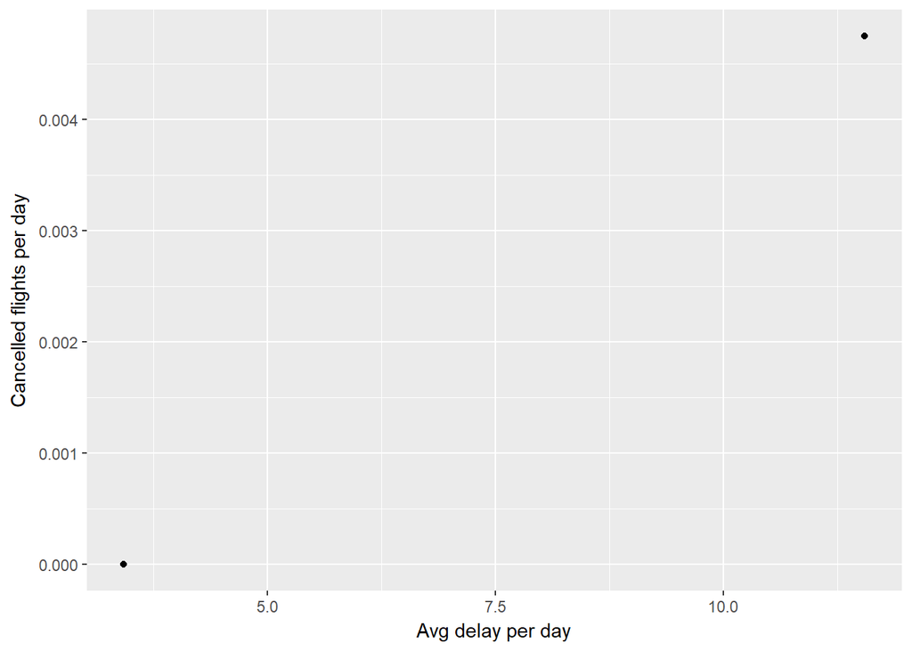

```r
flights %>%
  group_by(month, day) %>%
  summarise(cancelled = mean(is.na(dep_delay)),
            mean_dep = mean(dep_delay, na.rm = T)) %>%
  ggplot(aes(y = cancelled)) +
  geom_point(aes(x = mean_dep)) +
  labs(x = "Avg delay per day", y = "Cancelled flights per day")
```

It looks like the average delay per day and the proportion of cancelled fights per day are positively correlated.

### **5.6.7.6**

```r
not_cancelled %>% count(dest, sort = T)
```

```
## # A tibble: 85 x 2
##    dest      n
##    <fct> <int>
##  1 ORD      56
##  2 ATL      50
##  3 MCO      48
##  4 FLL      47
##  5 LAX      46
##  6 CLT      39
##  7 MIA      39
##  8 SFO      39
##  9 DFW      30
## 10 BOS      29
## # ... with 75 more rows
```

The count argument sorts your case in descending order. You would use this when you want to sort in descending order. In this case we would use it if we wanted to see the top 10 destinations by number of flights that are not cancelled.

### **Extra Credit: 5.6.7.5**

Which carrier has the worst delays? Challenge: can you disentangle the effects of bad airports vs. bad carriers? Why/why not? (Hint: think about flights %>% group_by(carrier, dest) %>% summarise(n()))

```r
worst_delays <- flights %>%
  filter(dep_delay > 59 & arr_delay >59)
worst_delays %>% count(carrier, sort = T)
```

```
## # A tibble: 7 x 2
##   carrier     n
##   <fct>   <int>
## 1 EV         22
## 2 B6          9
## 3 MQ          9
## 4 AA          3
## 5 UA          3
## 6 9E          2
## 7 DL          2
```

This same exercise can be done but aggregated by origin or destination to find the airports with the worst delays.

## **Section 10.5**

### **10.5.1**

You can tell that an object is a tibble because when you print the object a comment will notify the user that the object is a tibble and the column type will appear beneath each column header. A tibble will also only display part of itself and then have a comment that describes the rest of the tibble.

### **10.5.2**

```r
df <- data.frame(abc = 1, xyz = "a")
df$x
```

```
## [1] a
## Levels: a
```

```r
tbl <- as_tibble(df)
tbl$x
```

The $ command on the dataframe autocompleted the column name from “x” to “xyz.” Whereas when you run this on a tibble it returns an error because “x” is not a complete column name.

```r
df[, "xyz"]
```

```
## [1] a
## Levels: a
```

```r
tbl[,"xyz"]
```

```
## # A tibble: 1 x 1
##   xyz
##   <fct>
## 1 a
```

```r
df[, c("abc", "xyz")]
```

```
##   abc xyz
## 1   1   a
```

```r
tbl[, c("abc", "xyz")]
```

```
## # A tibble: 1 x 2
##     abc xyz
##   <dbl> <fct>
## 1     1 a
```

Using brackets [] with a dataframe returns different objects depending on the number of columns. If you are returning one column, it will return a vector not a dataframe. This could cause some frustration if you didn’t know how many columns a command would return. If you were using this command on a dataframe you would need to account for a one column edge case.

### **10.5.3**

If you have the name of a variable stored in an object you would need to us the bracket command([]) to extract the variable because the $ command is used to extract columns.

### **10.5.6**

The option that controls the number of additional column names at the footer of a tibble is (n_extra).

## **Section 12.3.3**

### **12.3.3.2**

```
table4a %>%
  gather(1999, 2000, key = "year", value = "cases")
```

This code breaks you need to put quotes around the variable names you want to gather. This code is looking for the 1999th and 2000th column of the data frame. Corrected code below:

```r
table4a %>%
  gather('1999', '2000', key = "year", value = "cases")
```

```
## # A tibble: 6 x 3
##   country     year   cases
##   <chr>       <chr>  <int>
## 1 Afghanistan 1999     745
## 2 Brazil      1999   37737
## 3 China       1999  212258
## 4 Afghanistan 2000    2666
## 5 Brazil      2000   80488
## 6 China       2000  213766
```

### **12.3.3.3**

```r
people <- tribble(
  ~name,             ~key,    ~value,
  #-----------------|--------|------
  "Phillip Woods",   "age",       45,
  "Phillip Woods",   "height",   186,
  "Phillip Woods",   "age",       50,
  "Jessica Cordero", "age",       37,
  "Jessica Cordero", "height",   156
)
```

Spreading this tibble fails because Phillip Woods has two keys. This is most likely from Phillip Woods getting recorded in 2 different years. You could add another column and call it first_visit or number. Corrected code below:

```r
people <- tribble(
  ~name,             ~key,    ~value, ~number,
  #-----------------|--------|------|------
  "Phillip Woods",   "age",       45, 1,
  "Phillip Woods",   "height",   186, 1,
  "Phillip Woods",   "age",       50, 2,
  "Jessica Cordero", "age",       37, 1,
  "Jessica Cordero", "height",   156, 1
)
```

```r
spread(people, key, value)
```

```
## # A tibble: 3 x 4
##   name            number   age height
##   <chr>            <dbl> <dbl>  <dbl>
## 1 Jessica Cordero      1    37    156
## 2 Phillip Woods        1    45    186
## 3 Phillip Woods        2    50     NA
```

### **12.3.3.4**

```r
preg <- tribble(
  ~pregnant, ~male, ~female,
  "yes",     NA,    10,
  "no",      20,    12
)
```

You need to gather this tribble. The variables are: - pregnant: “yes” or “no” - female - count

```r
gather(preg, sex, count, male, female) %>%
  mutate(pregnant = pregnant ==  "yes",
         female = sex == "female")
```

```
## # A tibble: 4 x 4
##   pregnant sex    count female
##   <lgl>    <chr>  <dbl> <lgl>
## 1 TRUE     male      NA FALSE
## 2 FALSE    male      20 FALSE
## 3 TRUE     female    10 TRUE
## 4 FALSE    female    12 TRUE
```

## **Section 12.4.3**

### **12.4.3.1**

```r
tibble(x = c("a,b,c", "d,e,f,g", "h,i,j")) %>%
  separate(x, c("one", "two", "three"), extra = "drop")
```

```
## # A tibble: 3 x 3
##   one   two   three
##   <chr> <chr> <chr>
## 1 a     b     c
## 2 d     e     f
## 3 h     i     j
```

The ‘extra’ argument in the separate() verb controls what happens when there are too many pieces. You can either warn(sends a warning), drop(drops extra values), or merge(splits at most length(into) times).

```r
tibble(x = c("a,b,c", "d,e", "f,g,i")) %>%
  separate(x, c("one", "two", "three"), fill = "right")
```

```
## # A tibble: 3 x 3
##   one   two   three
##   <chr> <chr> <chr>
## 1 a     b     c
## 2 d     e     <NA>
## 3 f     g     i
```

The ‘fill’ argument controls what happens when there are not enough pieces. You can either warn(send a warning), right(fill with missing values on the right), or left(fill with missing values on the left).

### **12.4.3.2**

The ‘remove’ argument in unite() and separate() removes the input column from the output dataframe, the default is set to TRUE. You would se this to FALSE if you want to keep the old variable and the new variables.

## **BABY NAMES**

- Download the baby_names.txt file from Canvas which is in the Homework 4 assignment section.

```r
file_path <- 'C:/Users/Gregory Spathias/Documents/compscix-415-2-assignments/Homework/baby_names.txt'
baby_names <- read.delim(file = file_path, sep = "|")
```

- Load this file into R correctly and take a glimpse of the output.

```r
glimpse(baby_names)
```

```
## Observations: 30,000
## Variables: 5
## $ year <int> 1880, 1880, 1880, 1880, 1880, 1880, 1880, 1880, 1880, 188...
## $ sex  <fct> F, F, F, F, F, F, F, F, F, F, F, F, F, F, F, F, F, F, F, ...
## $ name <fct> Mary, Anna, Emma, Elizabeth, Minnie, Margaret, Ida, Alice...
## $ n    <int> 7065, 2604, 2003, 1939, 1746, 1578, 1472, 1414, 1320, 128...
## $ prop <dbl> 0.072384329, 0.026679234, 0.020521700, 0.019865989, 0.017...
```

- Export this file as a csv file and call it ‘baby_names.csv’.

```r
write.csv(baby_names, file = "C:/Users/Gregory Spathias/Documents/compscix-415-2-assignments/Homework/baby_names_export.csv")
```

- Reload the baby_names.csv file and take another glimpse.

```r
file_path <- 'C:/Users/Gregory Spathias/Documents/compscix-415-2-assignments/Homework/baby_names_export.csv'
baby_names_import <- read.csv(file = file_path)
```

```r
glimpse(baby_names_import)
```

```
## Observations: 30,000
## Variables: 6
## $ X    <int> 1, 2, 3, 4, 5, 6, 7, 8, 9, 10, 11, 12, 13, 14, 15, 16, 17...
## $ year <int> 1880, 1880, 1880, 1880, 1880, 1880, 1880, 1880, 1880, 188...
## $ sex  <fct> F, F, F, F, F, F, F, F, F, F, F, F, F, F, F, F, F, F, F, ...
## $ name <fct> Mary, Anna, Emma, Elizabeth, Minnie, Margaret, Ida, Alice...
## $ n    <int> 7065, 2604, 2003, 1939, 1746, 1578, 1472, 1414, 1320, 128...
## $ prop <dbl> 0.072384329, 0.026679234, 0.020521700, 0.019865989, 0.017...
```